# Draft1

Sam

December 11, 2014

**Quantitative Analysis of the Impact of Education on Entrepreneurship**

*Data Sources*

To complete a quantitative analysis of the impact of educational factors – specifically the encouragement of creatitivity, self-sufficiency, and personal initiative – on the country-level rate of entrepreneurship, we have drawn on publicly available data from the Global Entrepreneurship Monitor (GEM) National Expert Survey (NES) and Adult Population Survey (APS).

The Global Entrepreneurship Monitor project is an annual assessment of the entrepreneurial activity, aspirations, and attitudes of individuals across a wide range of countries. The countries covered have grown from a low of ten to covering 75% of world population and 89% of world GDP by 2013. The 2001-2010 multi-year APS data base, for example, contains over 1.3 million observations of a total of 85 countries. This data is often cited in academic research, including reports by the Organisation for Economic Co-operation and Development.

The NES is structured around nine entrepreneurial framework contitions evaluated by thirty-six experts in each surveyed country. These nine entrepreneurial framework conditions are included below (a minimum of four experts must be interviewed on each of the framework conditions).

1. Finance
2. Government policies
3. Government programs
4. Entrepreneurial Education and Training
5. Research and Development Transfer (R & D)
6. Commercial and professional infrastructure
7. Internal Market openness
8. Physical infrastructure and services
9. Cultural and social norms

The APS is a questionnaire distrubuted to a minimum of 2,000 adults in each participating country. The survey is created by a central GEM team, but the implementation is managed by national teams that compete for the role of implementing the survey. Experts are chosen based on experience and specialization and are expected to represent the entire country (including urban and rural areas).

**Data Selection**

After reviewing the available data, we decided to select the following variables for our analysis.

| Source | Indicator |
| --- | --- |
| APS | Rate of Entrepreneurship (Intention, Nascent, Established) |
| NES | Way of Teaching |
| APS | Perceived Capabilities |
| APS | Fear of Failure / Perceived Opportunities |
| APS | Perceived Opportunities |

The survey questions corresponding to these variables are as follows:

1. **Entrepreneurial Intention**: Percentage of 18-64 population (individuals involved in any stage of entrepreneurial activity excluded) who intend to start a business within three years.
2. **Nascent Entrepreneurship**: Percentage of 18-64 population who are currently a nascent entrepreneur, i.e., actively involved in setting up a business they will own or co-own; this business has not paid salaries, wages, or any other payments to the owners for more than three months.
3. **Established Entrepreneur**: Percentage of 18-64 population who are currently owner-manager of an established business, i.e., owning and managing a running business that has paid salaries, wages, or any other payments to the owners for more than 42 months.
4. **Way of Teaching**: In my country, teaching in primary and secondary education encourages creativity, self-sufficiency, and personal initiative.
5. **Perceived Capabilities**: Percentage of 18-64 population who believe to have the required skills and knowledge to start a business
6. **Fear of Failure**: Percentage of 18-64 population with positive perceived opportunities who indicate that fear of failure would prevent them from setting up a business.
7. **Perceived Opportunities**: Percentage of 18-64 population who see good opportunities to start a firm in the area where they live

The APS data represent the national-level average of values between 1 and 100 that were gathered as responses to surveys within each country. The NES data is calculated based on the average answer to a survey to the national experts. For each question, the experts surveyed had to state whether it is:

1. Completely false
2. Somewhat false
3. Neither true or false
4. Somewhat true
5. Completely true

(97. Do not know)  
(98. Not applicable)

The process of importing, cleaning, and analyzing all of the data used in this project is fully documented and reproducable by referencing our GitHub repository.

**Analytical Framework**

To understand the impact of educational factors – specifically the encouragement of creatitivity, self-sufficiency, and personal initiative – on the country-level rate of entrepreneurship we built our model as outlined in the table below.

| Variable | Indicator |
| --- | --- |
| Y Dependent Variable | Rate of Entrepreneurship (Intention, Nascent, Established) |
| X1 Explanatory Variable | Way of Teaching |
| X2 Control Variable | Perceived Capabilities |
| X3 Control Variable | Fear of Failure / Perceived Opportunities |
| X4 Control Variable | Perceived Opportunities |

Data on our explanatory variable, Way of Teaching, is available on the GEM website for the years 2001-2010. To illustrate the distribution of this data, we have created the following histogram. As shown in the histogram, the largest density of scores is approximately 2.3, which lies between the “somewhat false” and “neither true or false” categories. This is not a whole number because the scores given by each of the 4 experts surveyed for each frameork condition are averaged to create a national-level number. As discussed later in this paper, this presents some difficulties in drawing substantive conclusions from this data. Namely, a large number of indifferent responses complicate the process of determining the influence we would like to analyze.

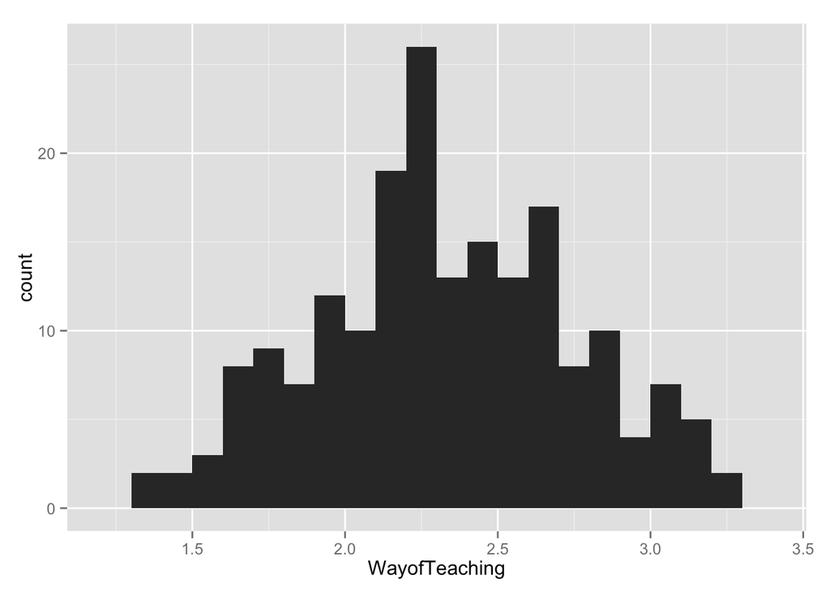

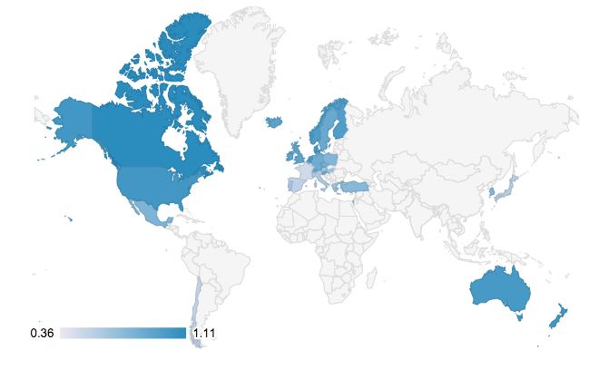

Starting with this explanatory variable, we built three regression equations to examine the impact of our explanatory variable on the rate of entrepreneurship (as measured by survey responses on the percentage of nascent entrepreneurs, established business owners, and respondents with the intention of becoming an entrepreneur). These three regression equations are as follows:

1. $PercentEntreIntention = \beta_1WayofTeaching + \beta_2PerceivedCabability + \beta_3PerceivedOpportunities$  
   $+ \beta_4FearFailure + \beta_5FearFailure*PerceivedOpportunities$
2. $PercentNascent = \beta_1WayofTeaching + \beta_2PerceivedCabability + \beta_3PerceivedOpportunities$  
   $+ \beta_4FearFailure + \beta_5FearFailure*PerceivedOpportunities$
3. $PercentOwner = \beta_1WayofTeaching + \beta_2PerceivedCabability + \beta_3PerceivedOpportunities$  
   $+ \beta_4FearFailure + \beta_5FearFailure*PerceivedOpportunities$

The interaction term $\beta_5FearFailure*PerceivedOpportunities$ was added to the regression because the survey question regarding “Fear of Failure” was only proposed to survey respondents who indicated they do perceive opportunities to start a business.

The simulations labeled “Unimputed” were created using only data collected from GEM. This simulation is not possible with missing data, so observations with missing data were omitted. In an attempt to increase the accuracy of this model, we used the R program Amelia to generate an imputed data frame. This program uses statistical inference to generate this data (more information on the Amelia package can be found on the program’s [CRAN page](http://cran.r-project.org/web/packages/Amelia/index.html)). Simulations titled “Imputed” were calculated using this imputed data frame.

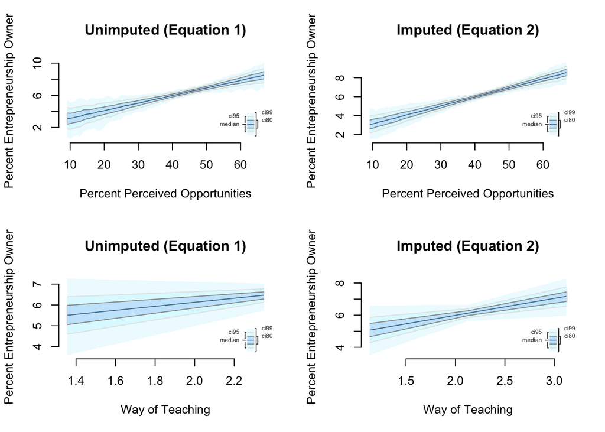